# Sentiment_Analysis

Garima Raghav

# INTRODUCTION

I have done the sentiment analysis and some Descriptive Examination for **Women’s Clothing E-Commersce Reviews**. This dataset contains more than 23,000 online reviews of women’s clothing from various retailers.

Sentiment Analysis also known as opinion mining, is the process of determining the emotional tone behind a series of words,used to gain an understanding of opinions and emotions.

It helps Data Analysts within large enterprise gauge public opinion , conduct market research and understand customer experiences.

# RENAMING & TIDYING UP

Here, I removed the first column that specified the row number and I renamed the columns.

```r
women <- read.csv(file= "/home/khalsa/sentiment Analysis/Womens Clothing E-Commerce Reviews.csv")
women <- women[-1]
colnames(women) <- c('ID', 'Age', 'Title', 'Review', 'Rating', 'Recommend', 'Liked', 'Division', 'Dept', 'Class')
```

```r
str(women)
```

```
## 'data.frame':    23486 obs. of  10 variables:
##  $ ID       : int  767 1080 1077 1049 847 1080 858 858 1077 1077 ...
##  $ Age      : int  33 34 60 50 47 49 39 39 24 34 ...
##  $ Title    : Factor w/ 13994 levels "","00 petite is way too short on the sides",..: 1 1 11318 8045 4355 8757 1953 10663 4278 11761 ...
##  $ Review   : Factor w/ 22635 levels "","120 lbs and i saw this while shopping with my sister who is 125 lbs. we both tried on the small and the fit was"| __truncated__,..: 141 13441 5011 6334 20319 7761 2696 8841 7117 7867 ...
##  $ Rating   : int  4 5 3 5 5 2 5 4 5 5 ...
##  $ Recommend: int  1 1 0 1 1 0 1 1 1 1 ...
##  $ Liked    : int  0 4 0 0 6 4 1 4 0 0 ...
##  $ Division : Factor w/ 4 levels "","General","General Petite",..: 4 2 2 3 2 2 3 3 2 2 ...
##  $ Dept     : Factor w/ 7 levels "","Bottoms","Dresses",..: 4 3 3 2 6 3 6 6 3 3 ...
##  $ Class    : Factor w/ 21 levels "","Blouses","Casual bottoms",..: 7 5 5 15 2 5 10 10 5 5 ...
```

```r
unlist(map(map(women, is.na), sum))
```

```
##        ID       Age     Title    Review    Rating Recommend     Liked  Division
##         0         0         0         0         0         0         0         0
##      Dept     Class
##         0         0
```

```r
clothesr <- women %>% filter(!is.na(Review))
notitle <- clothesr %>% filter(is.na(Title)) %>% select(-Title)
wtitle <- clothesr %>% filter(!is.na(Title)) %>% unite(Review, c(Title, Review), sep = ' ')

main <- bind_rows(notitle, wtitle)
 unlist(map(map(main, is.na), sum))
```

```
##        ID       Age    Review    Rating Recommend     Liked  Division      Dept
##         0         0         0         0         0         0         0         0
##     Class
##         0
```

```r
 write.csv(main, file="/home/khalsa/sentiment Analysis/Tidydata.csv")
```

# Stastical Testing

## USING CHI_SQUARED TEST

```r
tidyD <- read.csv(file= "/home/khalsa/sentiment Analysis/Tidydata.csv")

#hypothesis :- Rating and Liked(+ve Feedback) of products must be interrelated

table(tidyD$Rating)
```

```
##
##     1     2     3     4     5
##   842  1565  2871  5077 13131
```

```r
table(tidyD$Liked)
```

```
##
##     0     1     2     3     4     5     6     7     8     9    10    11    12
## 11176  4043  2193  1433   922   673   525   374   319   261   225   178   146
##    13    14    15    16    17    18    19    20    21    22    23    24    25
##   102   121    94    74    81    62    54    40    30    29    31    21    25
##    26    27    28    29    30    31    32    33    34    35    36    37    38
##    23    20    24    15    18    17    10     6     7     6     6     9     8
##    39    40    41    42    43    44    45    46    47    48    49    50    51
##     4     3     3     9     4     3     4     2     3     1     2     1     5
##    52    53    54    55    56    57    58    59    61    64    65    66    68
##     1     2     1     2     1     3     2     1     1     1     4     1     1
##    69    71    77    78    81    82    84    87    89    93    94    95    98
##     1     1     1     1     4     1     1     1     1     1     1     1     1
##    99   108   117   122
##     1     1     1     1
```

```r
table(tidyD$Rating,tidyD$Liked)
```

```
##
##        0    1    2    3    4    5    6    7    8    9   10   11   12   13   14
##   1  343  131   81   59   37   35   27   15   10   12    9    7   11   13    5
##   2  624  244  160  103   90   57   43   37   28   25   30   20   10    7   17
##   3 1233  501  271  173  114  121   83   55   35   34   27   25   17   17   21
##   4 2508  844  497  293  199  133  102   70   64   63   46   34   27   19   17
##   5 6468 2323 1184  805  482  327  270  197  182  127  113   92   81   46   61
##
##       15   16   17   18   19   20   21   22   23   24   25   26   27   28   29
##   1    8    3    8    3    1    4    3    1    0    2    1    2    1    2    0
##   2    9    5    7    6    2    4    3    2    2    2    2    3    4    1    1
##   3   18   20   13    7    7    5    3    8    7    1    5    4    2    5    2
##   4   20    8   11   15   14    8   10    3    6    8    9    6    1    2    5
##   5   39   38   42   31   30   19   11   15   16    8    8    8   12   14    7
##
```

[output cut: 27 more lines]

```r
#checking statistical independance between rating and liked(+ve feedback) using chi-squared test
#as we have categorical data
summary(table(tidyD$Rating,tidyD$Liked)) #less p-value indicates there is no realtion
```

```
## Number of cases in table: 23486
## Number of factors: 2
## Test for independence of all factors:
##  Chisq = 601.6, df = 324, p-value = 6.529e-19
##  Chi-squared approximation may be incorrect
```

```r
#between rating and liking of any product, not compulsurily highly rated product got more likes
#but practically speaking -> highly rated got more likes compared to others

mean(tidyD$Rating) #true mean
```

```
## [1] 4.196032
```

```r
sd(tidyD$Rating)   #true SD
```

```
## [1] 1.110031
```

```r
#NORMALIZING DATA
scale(tidyD$Rating)
```

[output not shown]

[output cut: 23476 more lines]

```r
str(tidyD)
```

```
## 'data.frame':    23486 obs. of  10 variables:
##  $ X        : int  1 2 3 4 5 6 7 8 9 10 ...
##  $ ID       : int  767 1080 1077 1049 847 1080 858 858 1077 1077 ...
##  $ Age      : int  33 34 60 50 47 49 39 39 24 34 ...
##  $ Review   : Factor w/ 22638 levels " ","00 petite is way too short on the sides I ordered the black & white, 00 petite. i'm 5' 2\", 96 lbs. and i order"| __truncated__,..: 131 12723 18201 13506 6273 14484 2947 17257 6256 18830 ...
##  $ Rating   : int  4 5 3 5 5 2 5 4 5 5 ...
##  $ Recommend: int  1 1 0 1 1 0 1 1 1 1 ...
##  $ Liked    : int  0 4 0 0 6 4 1 4 0 0 ...
##  $ Division : Factor w/ 4 levels "","General","General Petite",..: 4 2 2 3 2 2 3 3 2 2 ...
##  $ Dept     : Factor w/ 7 levels "","Bottoms","Dresses",..: 4 3 3 2 6 3 6 6 3 3 ...
##  $ Class    : Factor w/ 21 levels "","Blouses","Casual bottoms",..: 7 5 5 15 2 5 10 10 5 5 ...
```

```r
x <- rnorm(100, mean = 4, sd=1)
x
```

```
##   [1] 4.822966 4.614040 5.279615 2.110516 2.831179 3.923434 2.927780 4.487424
##   [9] 1.820268 6.343585 2.858490 5.467983 3.592064 3.254768 3.736769 3.918029
##  [17] 5.402801 4.846943 3.916081 2.899413 5.026188 5.734688 4.118389 5.842694
##  [25] 4.358289 1.609324 4.406030 3.786039 5.546892 3.058850 3.378048 3.423662
##  [33] 4.674576 3.740204 4.069096 1.951102 5.214880 3.438105 4.432848 6.481290
##  [41] 3.911535 4.276012 3.430642 3.291318 2.972836 3.285057 4.684163 4.221847
##  [49] 5.193564 2.347274 3.912195 4.240868 5.082882 3.319361 3.417537 3.622381
##  [57] 3.854974 4.768827 6.254517 4.108697 5.464141 3.239274 5.457616 5.729739
##  [65] 6.427341 5.033516 4.339785 4.135277 3.174578 5.051644 5.586058 4.420418
##  [73] 4.541895 5.484785 4.371769 5.188109 4.246068 3.606229 4.018728 4.931719
##  [81] 3.302210 4.960695 2.939065 6.833884 4.971421 3.741646 3.450835 3.837236
##  [89] 3.630166 5.027398 4.745421 4.133989 4.248485 3.979331 4.425953 2.662960
##  [97] 3.244969 2.435834 3.822168 4.102133
```

```r
t.test(x, mu= 4, conf.level = 0.99) # p-value>0.05 indicating acceptance of null hypothesis
```

```
##
##  One Sample t-test
##
## data:  x
## t = 1.7323, df = 99, p-value = 0.08633
## alternative hypothesis: true mean is not equal to 4
## 99 percent confidence interval:
##  3.904592 4.465134
## sample estimates:
## mean of x
##  4.184863
```

```r
#confidence level for median
wilcox.test(x, conf.int = T) #rejecting null hypothesis
```

```
##
##  Wilcoxon signed rank test with continuity correction
##
## data:  x
## V = 5050, p-value < 2.2e-16
## alternative hypothesis: true location is not equal to 0
## 95 percent confidence interval:
##  3.955542 4.392158
## sample estimates:
## (pseudo)median
##       4.174322
```

```r
#ACC. to hypothesis let mean=4 with confidence of 80%
t.test(tidyD$Rating, mu= 4, conf.level = 0.80)#smaller p value indicated rejection of hypothesis
```

```
##
##  One Sample t-test
##
## data:  tidyD$Rating
## t = 27.064, df = 23485, p-value < 2.2e-16
## alternative hypothesis: true mean is not equal to 4
## 80 percent confidence interval:
##  4.186749 4.205314
## sample estimates:
## mean of x
##  4.196032
```

```r
#indicating mean is <4 or >4

#confidence level for median
wilcox.test(tidyD$Rating, conf.int = T) #rejecting null hypothesis
```

```
##
##  Wilcoxon signed rank test with continuity correction
##
## data:  tidyD$Rating
## V = 275807841, p-value < 2.2e-16
## alternative hypothesis: true location is not equal to 0
## 95 percent confidence interval:
##  4.499970 4.499961
## sample estimates:
## (pseudo)median
##       4.499996
```

```r
#Testing for NORMALITY
shapiro.test(x) #normally distributed
```

```
##
##  Shapiro-Wilk normality test
##
## data:  x
## W = 0.99371, p-value = 0.9268
```

```r
#checking for correlation between Rating and Id of product
#as our data is normally distributed we will use "PEARSON METHOD"

cor(tidyD$Rating, tidyD$ID)
```

```
## [1] -0.01887944
```

```r
cor.test(tidyD$Rating, tidyD$ID)# significant correlation doesn't exists
```

```
##
##  Pearson's product-moment correlation
##
## data:  tidyD$Rating and tidyD$ID
## t = -2.8937, df = 23484, p-value = 0.003811
## alternative hypothesis: true correlation is not equal to 0
## 95 percent confidence interval:
##  -0.031661117 -0.006091583
## sample estimates:
##         cor
## -0.01887944
```

```r
#that means a product with same ID must have got different ratings by different customers
#of different age group


#even the correlation between Customer Age and Product Id doesn't exist indicating
#Different choice for one particular age group
cor(tidyD$Age, tidyD$ID)
```

```
## [1] 0.01797237
```

```r
cor.test(tidyD$Age, tidyD$ID)
```

```
##
##  Pearson's product-moment correlation
##
## data:  tidyD$Age and tidyD$ID
## t = 2.7546, df = 23484, p-value = 0.005881
## alternative hypothesis: true correlation is not equal to 0
## 95 percent confidence interval:
##  0.005184242 0.030754631
## sample estimates:
##        cor
## 0.01797237
```

# Descriptive examination and Sentiment Analysis

## Top-20 Clothing ID

To understand the distribution.. firstly look at the sale of top products.

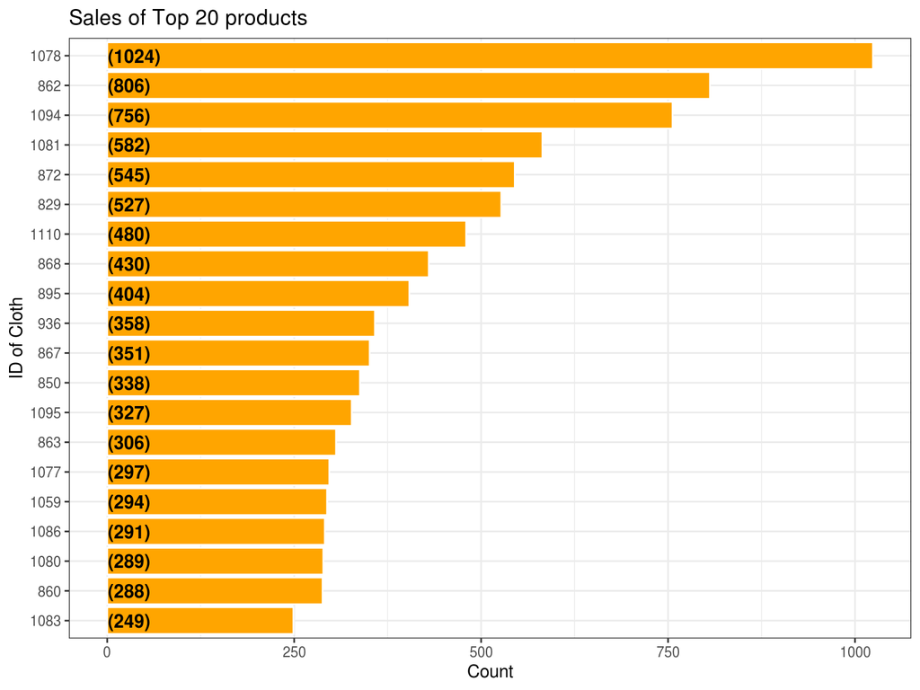

```r
REVIEWS = main %>%
  group_by(`ID`) %>%
  summarise(Count = n()) %>%
  arrange(desc(Count)) %>%
  ungroup() %>%
  mutate(clothid = reorder(`ID`,Count)) %>%
  head(20)

REVIEWS %>%
  ggplot(aes(x = clothid, y = Count)) +
  geom_bar(stat='identity',colour="white", fill = "orange") +
  geom_text(aes(x = clothid, y = 1, label = paste0("(",Count,")",sep="")),
            hjust=0, vjust=.5, size = 4, colour = 'black',
            fontface = 'bold') +
  labs(x = 'ID of Cloth',
       y = 'Count',
       title = 'Sales of Top 20 products') +
  coord_flip() +
  theme_bw()
```

Now look at Rating distribution of top products.

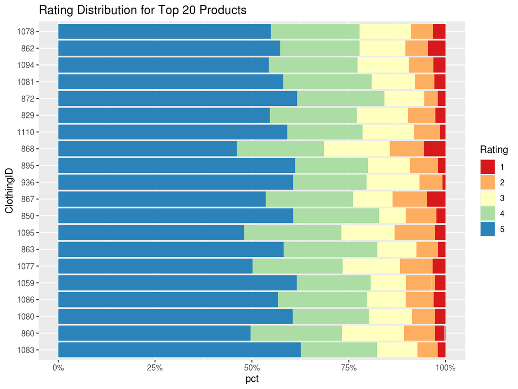

```r
top20<- main%>%
  group_by(ID)%>%
  add_count()%>%
  filter(n>245)

top20$Rating<- as.factor(top20$Rating)

top20%>%
  group_by(ID)%>%
  mutate(pct = n/sum(n))%>%
  ungroup()%>%
  mutate(ClothingID = reorder(ID, n))%>%
  ggplot(aes(ClothingID, pct, fill = Rating))+
  geom_col()+
  scale_fill_brewer(palette="Spectral")+
  coord_flip()+
  scale_y_continuous(labels = percent)+
labs(title = "Rating Distribution for Top 20 Products")
```

**There seems to be little correlation between how much sales a product has and the distribution of ratings given to it.**

I’d like to see which Department gets however much percentage of the reviews/ratings.

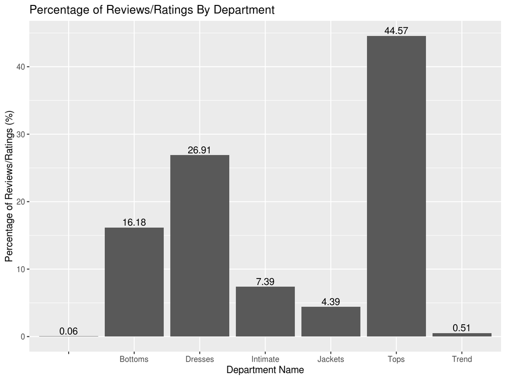

```r
ggplot(data.frame(prop.table(table(main$Dept))), aes(x=Var1, y = Freq*100)) + geom_bar(stat = 'identity') + xlab('Department Name') + ylab('Percentage of Reviews/Ratings (%)') + geom_text(aes(label=round(Freq*100,2)), vjust=-0.25) + ggtitle('Percentage of Reviews/Ratings By Department')
```

**Tops have the highest percentage of reviews and ratings in this dataset**, followed by dresses. Items in the Jackets and Trend department received the fewest reviews.

## Ratings by Department

I will be excluding ‘Trend’ as it contains a mix of clothes that can fit in the other categories of Dept. They also represent 119/23486 = 0.51% of the dataset so I don’t expect a large effect on the data analysis. I will focus on 5 departments: Bottoms, Dresses, Intimate, Jackets, and Tops. Now, most of the reviews/ratings are for Tops and the least, for Jackets.

Let’s look at the distribution of ratings within each department.

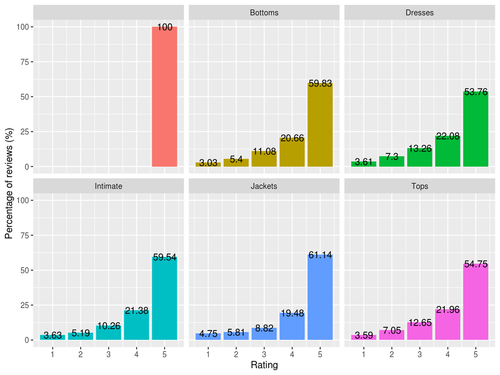

```r
#ratings percentage by Department
phisto <- main %>% filter(!is.na(Dept), Dept != 'Trend') %>% mutate(Dept = factor(Dept)) %>% group_by(Dept) %>% count(Rating) %>% mutate(perc = n/sum(n))
phisto %>% ggplot(aes(x=Rating, y = perc*100, fill = Dept)) + geom_bar(stat = 'identity', show.legend = FALSE) + facet_wrap(~Dept) + ylab('Percentage of reviews (%)') + geom_text(aes(label=round(perc*100,2)))
```

In each Department, the dominant rating given is 5-stars. **Jacket has the highest number of 5-star ratings within its department**. The Jacket department also had to fewest number of reviews which could mean that if the number of ratings/reviews were to increase, there may not be as big of a gap between 5-star and other-star reviews. As far as I can tell, jackets may be a good investment as consumers seem to give more 5-star reviews.

## Recommendation By Age

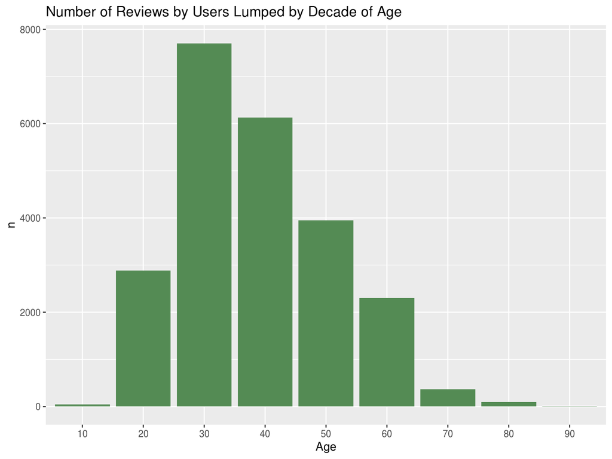

```r
main<- main%>%
  mutate(Age = 10 * (Age%/%10), Rating)
main$Age<- as.factor(main$Age)
main$Rating<- as.factor(main$Rating)

main%>%
  group_by(Age)%>%
  summarize(n = n())%>%
  ggplot(aes(Age, n))+
  geom_col(fill = "palegreen4")+
labs(title = "Number of Reviews by Users Lumped by Decade of Age")
```

Insight: Age is normally distributed, and slightly skewed right. With the majority of users aged between 30-50.

## Ratings in dependency of other variables: Lattice graphs

Lattice graphs can show easly possible relations between the variables.

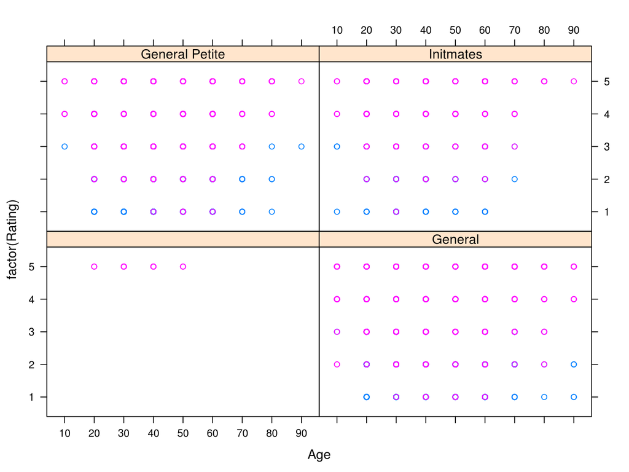

```r
xyplot(factor(Rating) ~ Age|factor(`Division`), groups = factor(`Recommend`),
        data = main)
```

Insight:graoh shows with its colouring from red to blue that lower ratings are more likely to not being recommended.It seems that with growing age the rating and the recommendation behaviour gets more strict.

## tokenization: analysing Reviews

To tokenize the words, I used the TidyText package which allows me to filter out the stop words (and, I, us, ect). I want to tokenize Review

sorting out the stop words and removed any digits.

I grouped the words according to their Ratings and plotted the 10 most common bigrams for each rating.

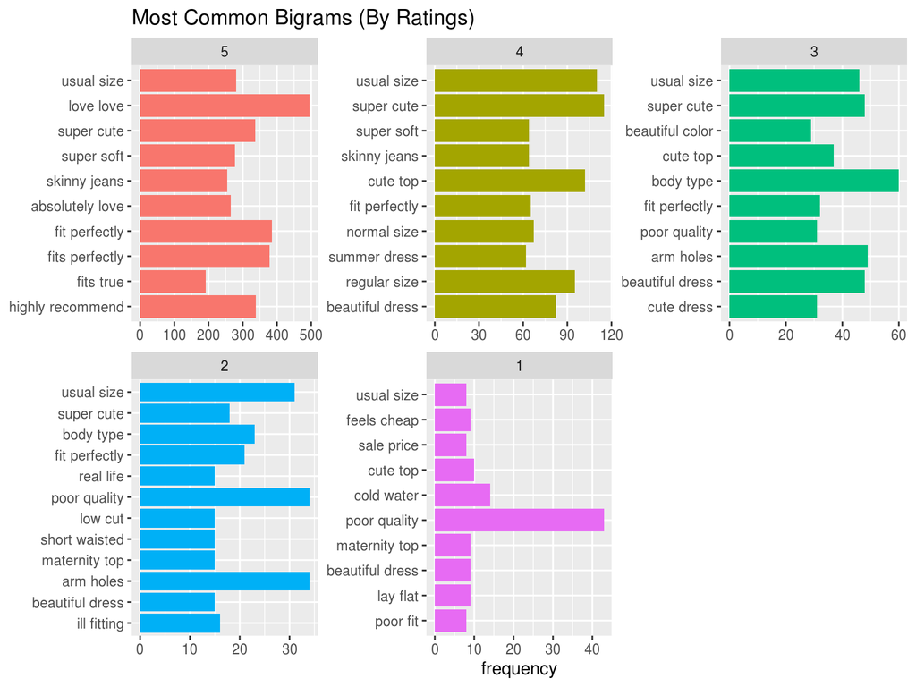

```r
top_bigrams <- bigramming(main) %>% mutate(Rating = factor(Rating, levels <- c(5:1))) %>% mutate(bigram = factor(bigram, levels = rev(unique(bigram)))) %>% group_by(Rating) %>% count(bigram, sort=TRUE) %>% top_n(10, n) %>% ungroup()

top_bigrams  %>% ggplot(aes(bigram, n, fill = Rating)) + geom_col(show.legend = FALSE) + facet_wrap(~Rating, ncol = 3, scales = 'free') + labs(x=NULL, y = 'frequency') + ggtitle('Most Common Bigrams (By Ratings)') + coord_flip()
```

It goes without saying that there are positive phrases for the higher ratings and negative phrases for the lower ratings. ‘Love love’ is the most mentioned bigram. The phrase ‘arm holes’ show up in 2,3-star reviews, which could refer to a lack of fit.

## WORDCLOUDS

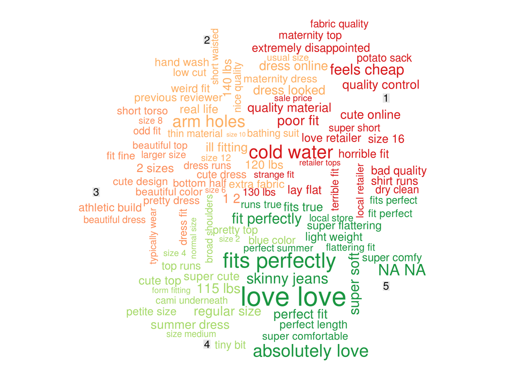

```r
rate.cols <- c("#d7191c", "#fdae61", "#fc8d59", "#a6d96a", "#1a9641")
by.rating <- as.data.table(main %>%
  unnest_tokens(bigram, `Review`, token = "ngrams", n = 2) %>%
  separate(bigram, c("word1", "word2"), sep = " ") %>%
  filter(!word1 %in% stop_words$word) %>%
  filter(!word2 %in% stop_words$word) %>%
  unite(bigram.unite, word1, word2, sep = " ", remove = FALSE) %>%
  count(bigram.unite, Rating, sort = TRUE))

by.pct <- by.rating[, gr.pct := n/sum(n), by = Rating]

by.rating %>%
  group_by(Rating) %>%
  top_n(n = 40, wt = gr.pct) %>%
  acast(bigram.unite ~ Rating, value.var = "gr.pct", fill = 0) %>%
  comparison.cloud(title.size = 1, random.order = TRUE,
                   colors = rate.cols)
```

MOST USED WORDS:-

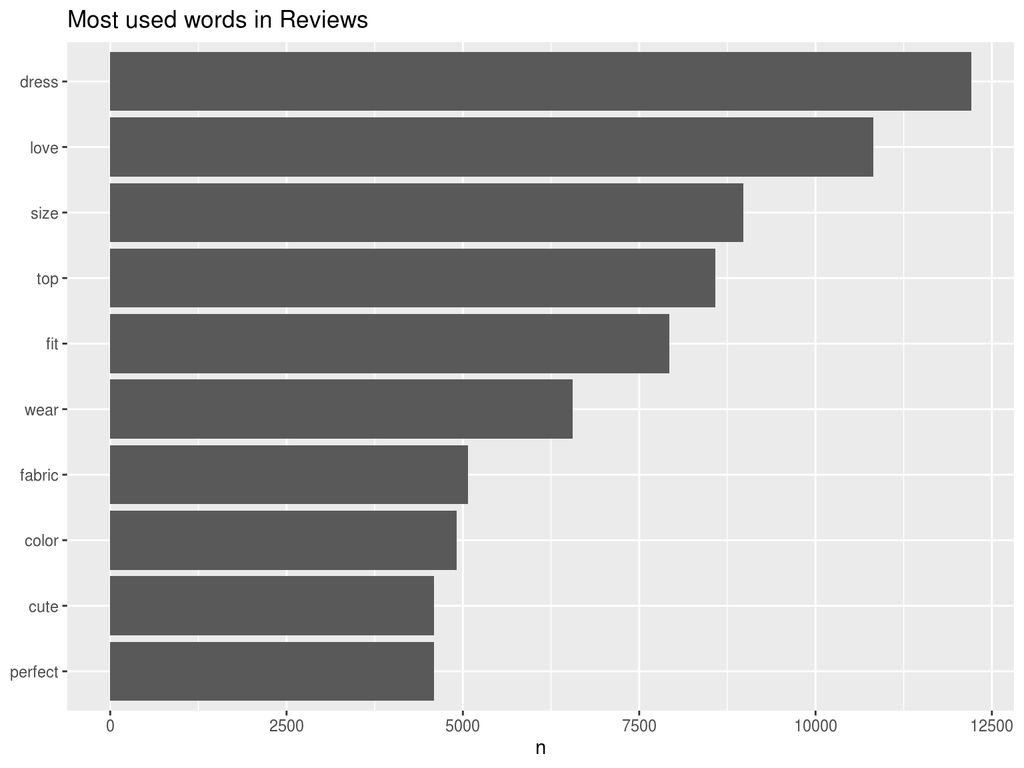

```r
main %>%
  unnest_tokens(word, `Review`) %>%
  anti_join(stop_words) %>%
  count(word, sort = TRUE) %>%
  head(10) %>%
  mutate(word = reorder(word, n)) %>%
  ggplot(aes(word, n)) +
  geom_col() +
  labs(x = NULL, title = "Most used words in Reviews") +
  coord_flip()
```

Insight:More clarity is given as to why a word is related to a Rating

## checking for corelation of sentiments with ratings

```r
main_bigrams <- main%>%
  na.omit()%>%
  unnest_tokens(bigram, Review, token = "ngrams", n = 1)

bing<- get_sentiments("bing")

names(main_bigrams)[names(main_bigrams) == "bigram"] <- "word"

sentiment <- main_bigrams%>%
  inner_join(bing)
```

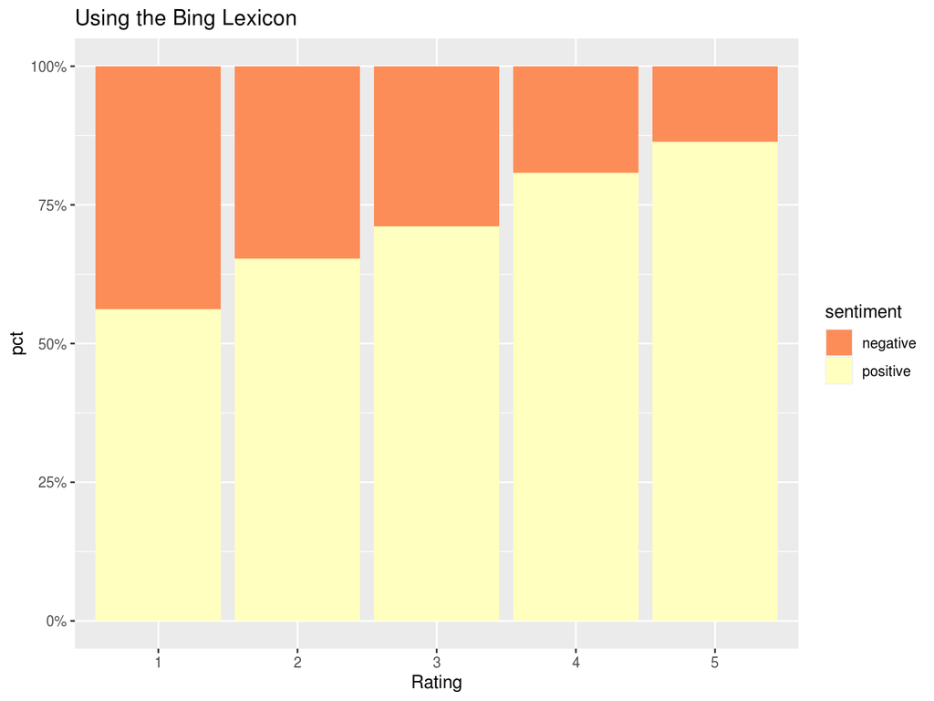

```r
sentiment%>%
  group_by(Rating, sentiment)%>%
  summarize(n = n())%>%
  mutate(pct = n/sum(n))%>%
  ggplot(aes(Rating, pct, fill= sentiment))+
  geom_col()+
  scale_fill_brewer(palette="Spectral")+
  scale_y_continuous(labels = percent)+
labs(title = "Using the Bing Lexicon")
```

Insight: sentiment seems to be correlated with Rating

# Conclusion

The key takeaways from the above analysis of this dataset are:

-> 5-star reviews are dominant in each department with jackets having the highest proportion within its department

-> Customers in their 30’s and 40’s leave the most reviews.

-> Tops have the highest percentage of reviews and ratings in this dataset followed by dresses

-> Sentiments are co-related with Ratings, the product with high ratings got more +ve reviews and recommendation